# Optimize Your Dev Setup For Evals w/ Cursor Rules & MCP

Author

Isaac Flath

Published

July 15, 2025

# 1 Why bother?

- Better AI assistance
- Training cutoff may mean outdated info
- Spending time determining what’s important to your project is good - Forces you to understand your tools better
- Make AI better match your taste
- Show how AI integrates with your other tools, abstractions, or framework

# 2 The Three Layers

1. **General Context**: Generic tool that works on almost anything
   - Repomix, GitMCP, etc.
2. **Curated Context**: Curated by an expert, such as the tool author
   - Library provided MCP, llms.txt, etc.
3. **Personalized Context**: Context that you can create that’s unique to your project
   - Only you can make this

# 3 General Context

**Good For**

- Good starting point when exploring or unsure about a tool
- Generic and not optimized for specific needs
- Fast and easy to set up
- Useful for quick experimentation and exploration

**_**

**Braintrust**

### 3.0.1 Repo Mix

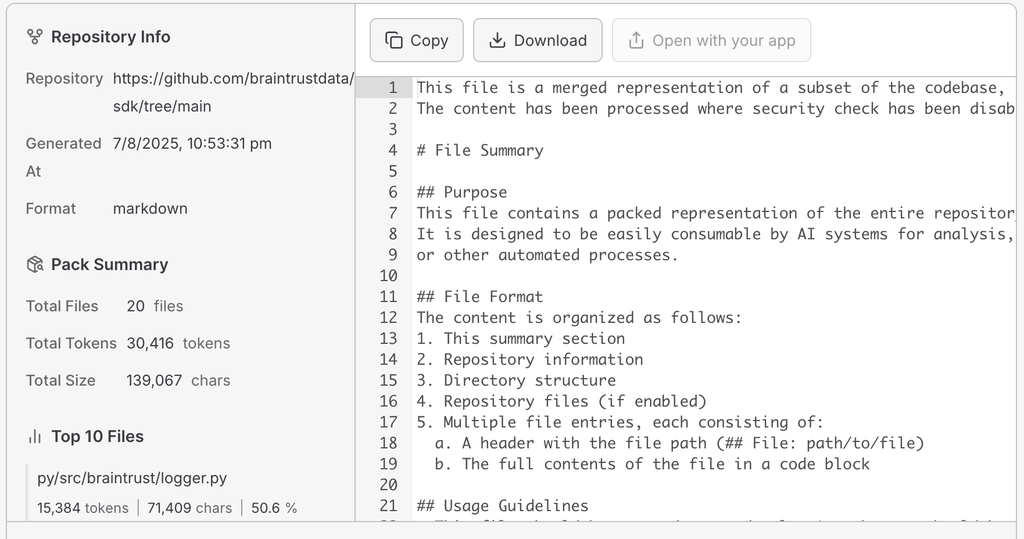

Repo Mix UI for Braintrust

**Phoenix**

### 3.0.2 Paste Max

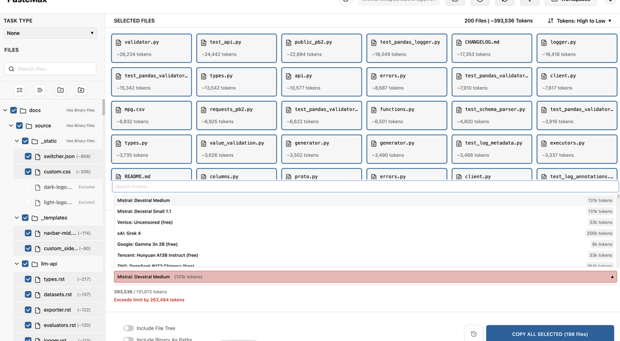

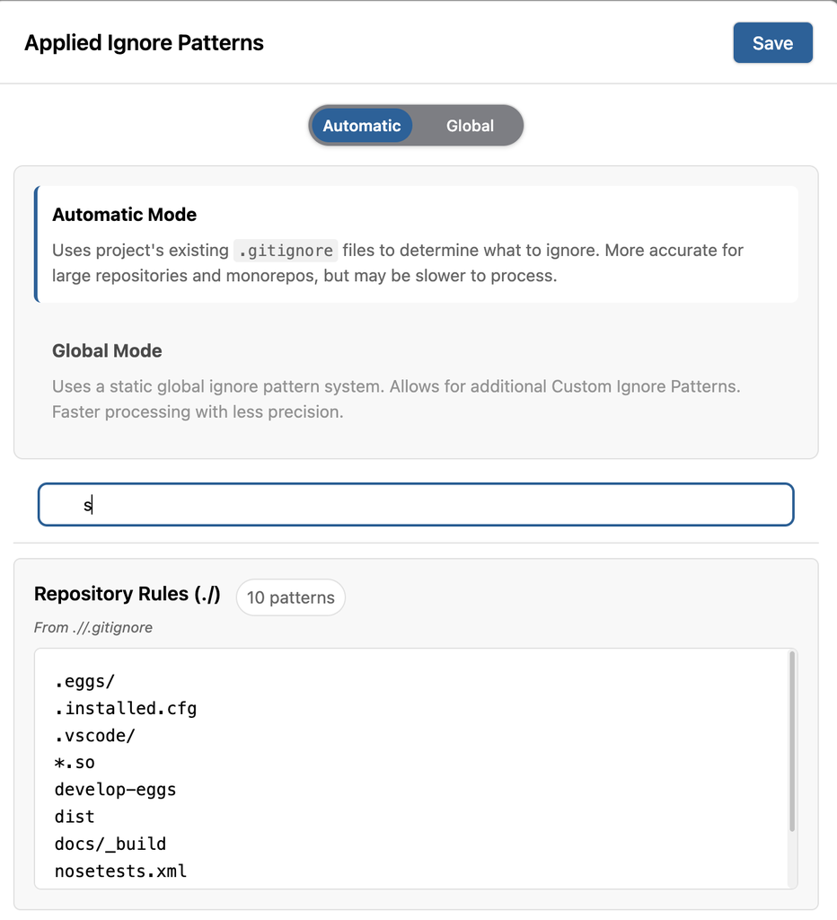

**Inspect**

### 3.0.3 Git MCP

- Repository chat interface: https://gitmcp.io/UKGovernmentBEIS/inspect_evals/chat

[figure not shown]

Chat interface

[figure not shown]

MCP interface

# 4 Cursor Rules

Cursor rules let you customize how the curso AI assistance will use your rules, this is extremely helpful and should not be overlooked.

## 4.1 Rule Creation

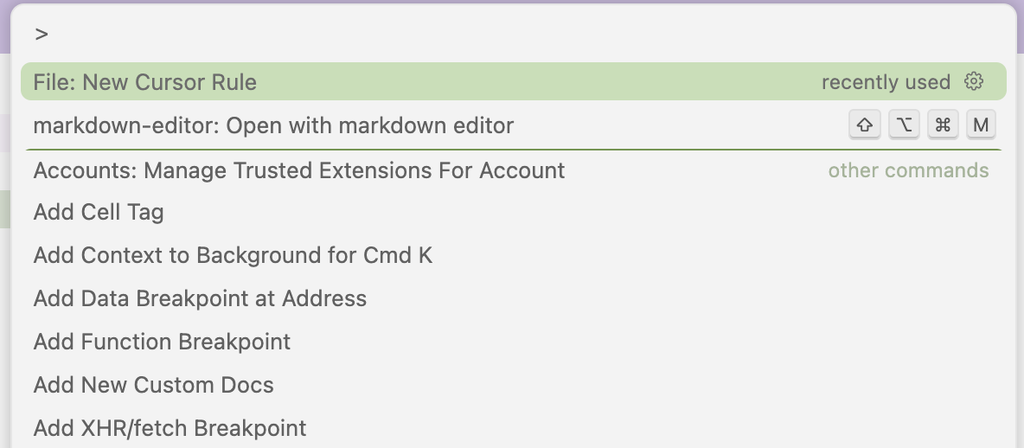

Cursor Rule Creation

## 4.2 Choosing a Rule Type

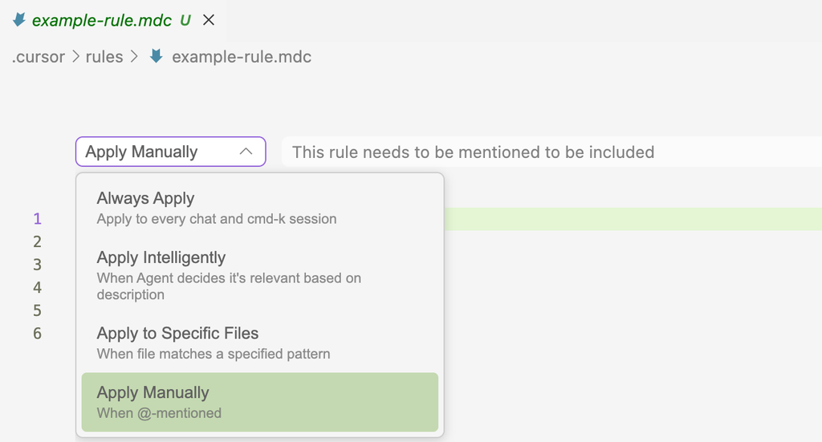

Cursor Rule Types

**Rule Application Strategies**

1. **Always Apply** - Core rules that should never be violated
2. **Apply Manually** - Rules you trigger when needed. If you’re really bad at thinking about context, and you’re not going to put a lot of effort in then don’t use this.
3. **Apply Intelligently** - This is a great thing to use
4. **Apply to Specific Files** - File-type or path-specific rules. This can be nice, but you’re liable to set it to a path, restructure something, then forget and this rule will be accidentlaly deprecated.

# 5 Curated Context

**Good For**

- You want to explore more deeply
- It’s provided by the tool author in some format

**_**

**Braintrust**

#### 5.0.0.1 MCP (Model Context Protocol)

- Official MCP server: https://www.braintrust.dev/docs/reference/mcp
- Provides structured access to Braintrust functionality

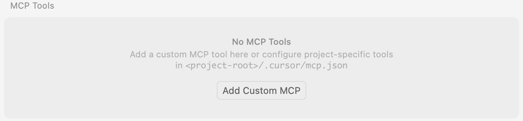

Cursor MCP Settings

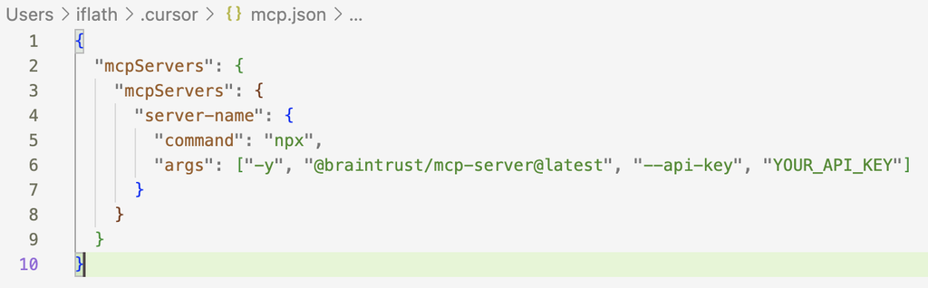

Cursor MCP Json

**Phoenix**

#### 5.0.0.2 LLMs .txt

- Standard Format: https://arize.com/docs/phoenix/llms.txt
- MCP documentation tool: https://github.com/langchain-ai/mcpdoc

**Inspect**

#### 5.0.0.3 llms.txt

- Standard format: https://inspect.aisi.org.uk/llms.txt
- Full version: https://inspect.aisi.org.uk/llms-full.txt
- Individual Pages as Context: https://inspect.aisi.org.uk/index.html.md

**Manual Approaches**

#### 5.0.0.4 Jina AI

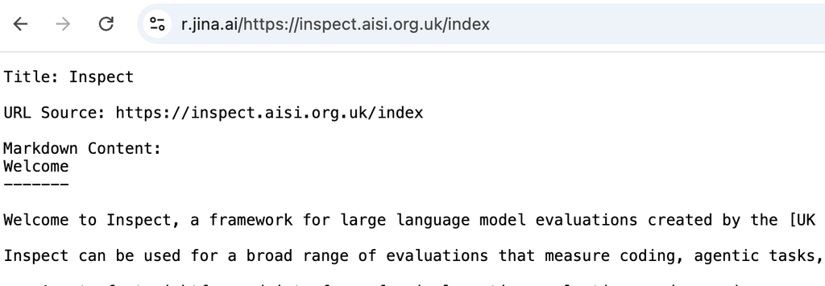

#### 5.0.0.5 Copy Outer HTML

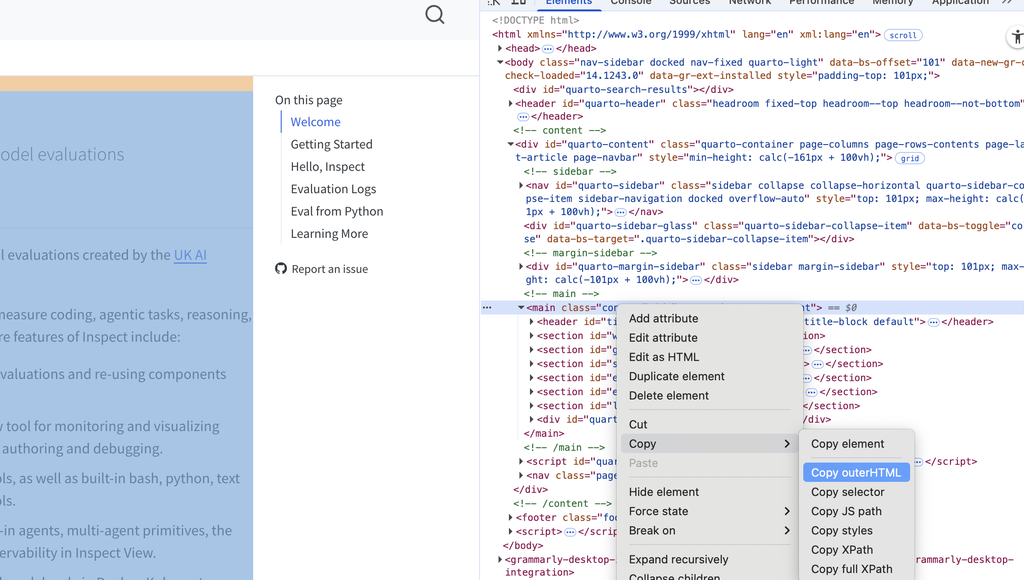

#### 5.0.0.6 Web 2 MD

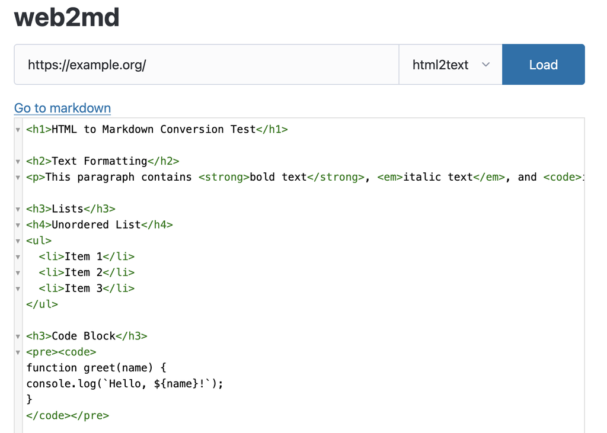

# 6 Personalized Context

**Good For**

- You know you’re going to be using this thing for months
- It’s worthwhile to invest a bit of time for better AI assistance

**_**

**Braintrust**

#### 6.0.0.1 Use Case Specific Context

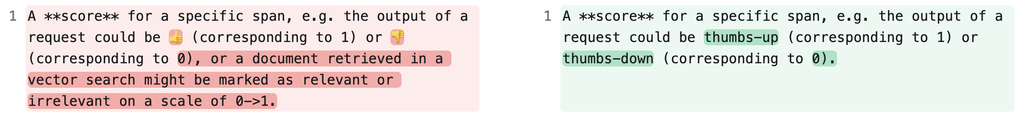

Use case specific examples

#### 6.0.0.2 Reducing Context Size

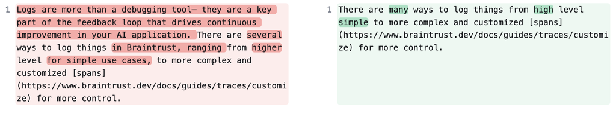

Reducing context for efficiency

#### 6.0.0.3 Opinionated Best Practices

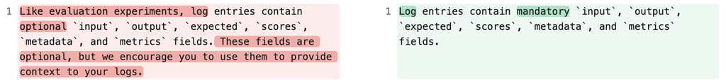

Defining coding standards

#### 6.0.0.4 Multi-Language Support

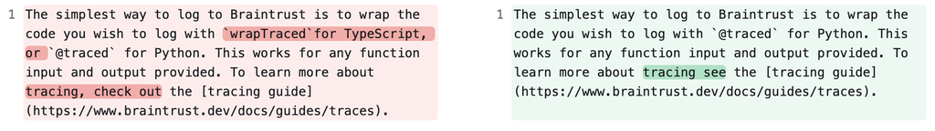

#### 6.0.0.5 Code Style Preferences

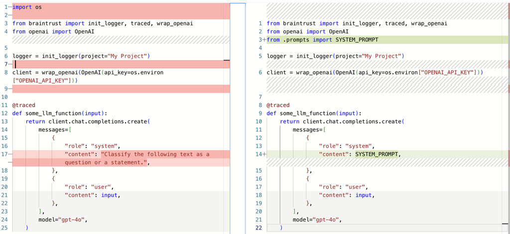

Insert your coding style

#### 6.0.0.6 Performance Considerations

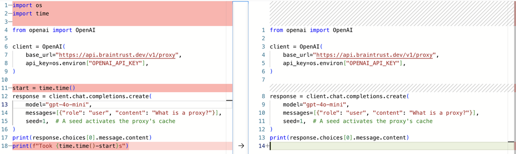

Removing timing-specific code

**Phoenix**

#### 6.0.0.7 Fix Formatting

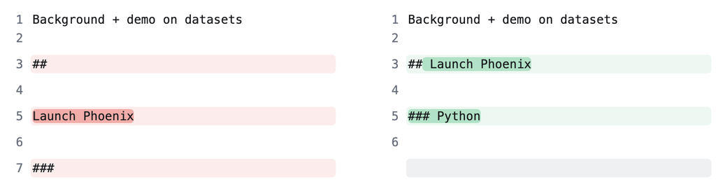

Fix Formatting

#### 6.0.0.8 Rm hosted options you’re not using

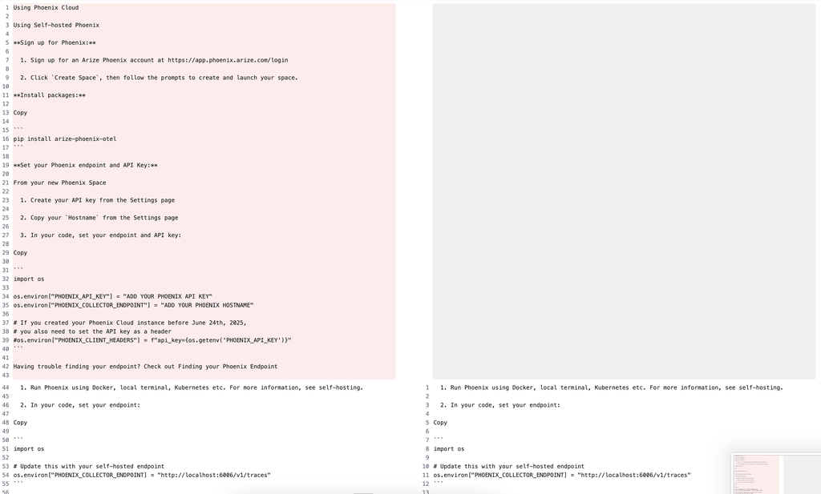

Remove Cloud Hosting

#### 6.0.0.9 Put in project specific info

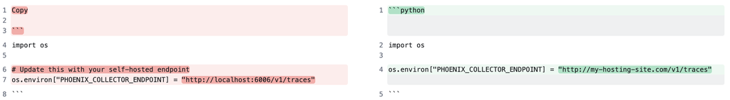

Put in Real Endpoints

#### 6.0.0.10 Remove Unused Languages

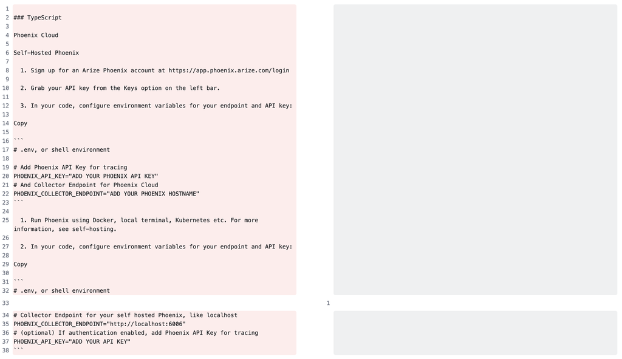

Remove Typescript

**Inspect**

#### 6.0.0.11 Human prose -> AI Instruction

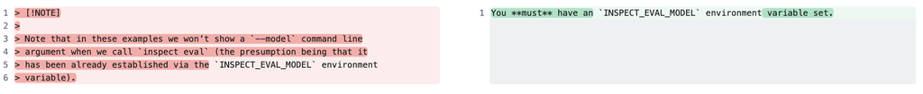

Change tip to instruction for env var clarity

#### 6.0.0.12 Remove examples not relevant to you

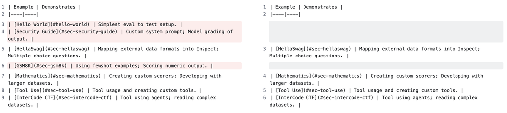

Remove non-relevant examples